[Статьи]

# Подбор регулирующего клапана линии рециркуляции масляного насоса объёмного типа

[figure not shown]

Рассмотрим следующую схему. Имеется насос объёмного типа Н, предназначенный для подачи масла из маслобака на подшипники турбины, на выходе из которых масло самотёком возвращается в маслобак.

$R_1$ - регулирующий клапан с переменным гидравлическим сопротивлением, $R_2$ - сопротивление трубопровода от напора насоса до выходного сечения маслопровода, подводящего масло к подшипнику, $h_1$ - отметка выходного сечения линии рециркуляции, $h_2$ - отметка выходного сечения подающего маслопровода.

Рассматриваемое масло - масло Тп-22.  
Теплофизические свойства масла Тп-22 https://openedu.urfu.ru/files/book/_static/pages/2.8.html

```python
# t = 35 - температура масла
dens = 885.4  # плотность, кг/м3
kvisc = 45e-6  # кинематическая вязкость, м2/с
```

```python
# Производительность насоса
Q_нас = 45  # м3/ч
# Суммарный требуемый расход масла на подшипники составляет
Q2_ном = 36  # м3/ч
# "Лишняя" подача насоса
Q1_ном = Q_нас - Q2_ном
Q1_ном  # м3/ч
```

```
9
```

Регулирование подачи насоса объёмного типа производится посредством отвода части расхода через линию рециркуляции обратно на всас насоса (см. [1]).

Известно, что расход на подшипники $Q_{ном}$ достигается при давлении за насосом

```python
p = 3e5  # Па(и)
```

Рассмотрим упрощённый способ подбора регулирующего клапана - без учёта сопротивления трубопровода линии рециркуляции и разницы высот между сечениями концов трубопроводов и отметкой напорного патрубка насоса.

Найдём сопротивление напорной линии насоса $R_2 = p / Q_{2\ ном}^2$ (см. [2])

Суммарный расход (подача насоса) равен сумме расходов обеих ветвей: $Q_{нас}=Q_1+Q_2$

Потери давления в обеих параллельных ветвях одинаковы $R_1 Q_1^2 = R_2 Q_2^2$

Заменив в вышеприведённом выражении $Q_2$ на $Q_{нас}-Q_1$, получим следующее квадратное уравнение с $Q_1$ в качестве неизвестного $x$:

$$(R_1 - R_2) x^2 + 2 R_2 Q_{нас} x - R_2 Q_{нас}^2\quad (1)$$

У данного квадратного уравнения имеются два корня $x_1$ и $x_2$:

$$x_1 = \frac{-b+\sqrt{D}}{2a};\quad x_2 = \frac{-b-\sqrt{D}}{2a},$$

где $a = R_1-R_2$; $b=2R_2Q_{нас}$; $c=-R_2Q_{нас}^2$; $D=b^2-4ac$.

Из двух корней выбираем тот, который соответствует условию $0\le x \le Q_{нас}$.

В линии рециркуляции установлен регулирующий клапан (далее - РК), сопротивление которого $R_1$ изменяется с изменением положения его штока. Чем выше значение условной пропускной способности $K_{VS}$ тем ниже его минимальное сопротивление (при полностью открытом РК). Сопротивление полностью закрытого РК (при условии его полной герметичности) равно бесконечности. Сопротивление и пропускная способность связаны друг с другом следующим выражением (см. [3]):

$$R = 100\rho/K_V^2$$

где $R$ - гидравлическое сопротивление, $Па\cdot час^2/м^6$; $\rho$ - плотность жидкости, $кг/м^3$; $K_V$ - пропускная способность, $м^3/ч$.

Проварьируем значение пропускной способности $K_V$ установленного в линии рециркуляции РК от 1 $м^3/ч$ до 100 $м^3/ч$, и решая для каждого случая квадратное уравнение (1), найдём зависимости расходов в ветвях от $K_V$ рассматриваемого РК.

```python
R1_ном = p / Q1_ном / Q1_ном
R2 = p / Q2_ном / Q2_ном
```

```python
# Решение квадратного уравнения (1) для заданного значения R1
def fQ1(R1):
    a = R1 - R2; b = 2 * R2 * Q_нас; c = - R2 * Q_нас * Q_нас
    D = b * b - 4 * a * c
    x1 = (-b + D ** 0.5) / 2 / a; x2 = (-b - D ** 0.5) / 2 / a
    x = x1
    if 0 <= x2 <= Q_нас:
        x = x2
    return x
```

```python
# Проверка функции fQ1
fQ1(R1_ном)  # Должна вернуть Q1_ном = 9 м3/ч
```

```
9.0
```

```python
# Получение данных для построения графиков
import numpy as np
Kvs = np.linspace(1, 100)  # массив значений пропускной способности
Q1s = np.empty_like(Kvs)  # массив значений расходов в линии рециркуляции
for i, Kv in enumerate(Kvs):
    R = 100 * dens / Kv / Kv
    Q1s[i] = fQ1(R)
```

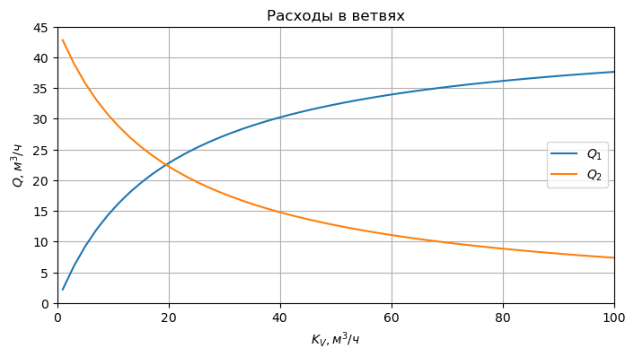

```python
import matplotlib.pyplot as plt
fig, ax = plt.subplots(figsize = (8, 4))
ax.set_title('Расходы в ветвях')
ax.set_xlabel('$K_V, м^3/ч$'); ax.set_ylabel('$Q, м^3/ч$')
ax.plot(Kvs, Q1s, label = '$Q_1$')
ax.plot(Kvs, Q_нас - Q1s, label = '$Q_2$')
ax.legend()
ax.set_xlim(0, Kvs[-1]); ax.set_ylim(0, Q_нас); ax.grid()
```

Теперь рассмотрим случай, когда через линию рециркуляции проходит вся подача насоса $Q_{нас}=45\, м^3/ч$. Чем меньше $K_V$ тем больше значение гидравлического сопротивления $R$ и тем больший напор должен создавать насос для "проталкивания" расхода $Q_{нас}$.

```python
ps = np.empty_like(Kvs)  # массив значений давлений
for i, Kv in enumerate(Kvs):
    R = 100 * dens / Kv / Kv
    ps[i] = R * Q_нас * Q_нас / 1e6
```

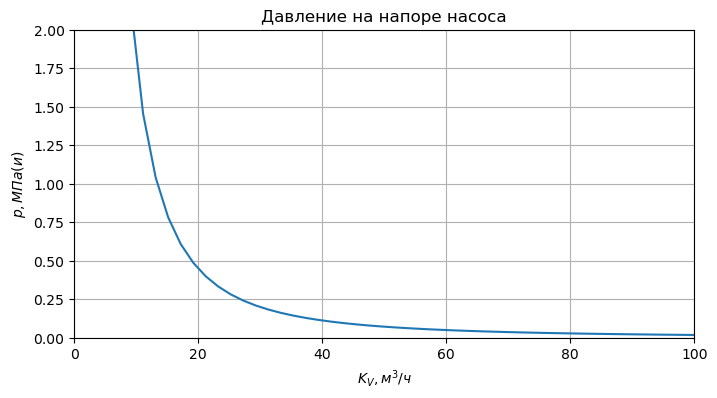

```python
fig, ax = plt.subplots(figsize = (8, 4))
ax.set_title('Давление на напоре насоса')
#ax.label = RHs
ax.set_xlabel('$K_V, м^3/ч$'); ax.set_ylabel('$p, МПа(и)$')
ax.plot(Kvs, ps)
ax.set_xlim(0, Kvs[-1]); ax.set_ylim(0, 2); ax.grid()
```

Для обеспечения требуемого расхода масла на подшипники $Q_{2\ ном} = 36\ м^3/ч$ через линию рециркуляции следует направить $Q_{1\ ном}=9\ м^3/ч$. Определим $K_{V\ ном}$ при котором расход в линии рециркуляции будет составлять $Q_{1\ ном}=9\ м^3/ч$.

```python
from math import sqrt
# R = 100 * dens / Kv / Kv отсюда
Kv_ном = sqrt(100 * dens / R1_ном)
Kv_ном
```

```
4.8893557857860985
```

Найдём $K_{V\ ном}$, используя `fQ1`, тем самым проверив корректность данной функции.

```python
from scipy.optimize import root_scalar
def f(Kv):
    R = 100 * dens / Kv / Kv
    return fQ1(R) - Q1_ном
```

```python
Kv_ном2 = root_scalar(f, bracket = [1, 10]).root
# Относительная разница, %
(Kv_ном2 - Kv_ном) / Kv_ном * 100
```

```
-8.174497957930806e-13
```

```python
# Давление на напоре насоса при котором Q2 = 45 м3/ч при Kv = Kv_ном = 4,9 м3/ч
R1_ном * Q_нас * Q_нас / 1e6  # МПа(и)
```

```
7.500000000000001
```

Для обеспечения требуемого расхода масла на подшипники $Q_{2\ ном} = 36\ м^3/ч$ через линию рециркуляции следует направить $Q_{1\ ном}=9\ м^3/ч$. Это достигается установкой штока регулирующего клапана в положение, при котором его пропускная способность составит $K_V=4.9\ м^3/ч$. При этом для направления через линию рециркуляции расхода $Q_{нас}=45\, м^3/ч$ давление на напоре насоса должно составлять 7,5 МПа(и), что для многих насосов является недопустимо большой величиной.

Поэтому если требуется иногда направлять всю подачу насоса через линию рециркуляции, то следует выбрать РК с большим $K_{VS}$ (при котором значение давления на напоре насоса будет допустимым) и предусмотреть два режима его работы: 1 - РК полностью открыт и его $K_V = K_{VS}$, 2 - РК установлен в положение $K_V=4.9\ м^3/ч$.

### Учёт сопротивления трубопровода линии рециркуляции и высотных отметок

Для учёта сопротивления трубопровода линии рециркуляции необходимо расcчитать его гидравлическое сопротивление $R_{тр}$ (см. [4]) и во всех формулах вместо $R_1$ подставлять $(R_1+R_{тр})$.

Для учёта $h_1$ и $h_2$ следует вместо формулы $\Delta p = RQ^2$ использовать формулу $\Delta p = RQ^2 + \rho gh$, где $\Delta p$ - потери давления в рассматриваемом участке, Па; $R$ - гидравлическое сопротивление участка, $Па\cdot час^2/м^6$, $Q$ - расход, $м^3/ч$; $h$ - разница высот конца и начала участка трубопровода, м; $\rho$ - плотность жидкости, $кг/м^3$; $g=9.81$ - ускорение свободного падения, $м/с^2$.

### Ссылки

1. [Различия в способах регулирования подачи динамических и объёмных насосов](https://dzen.ru/a/ZYbPskJmzHvbKs6W)
2. [Моделирование характеристики гидравлической сети](https://medsv.github.io/dzen/0015/network.html)
3. [Что такое KV и как его использовать](https://medsv.github.io/dzen/0006/Kv.html)
4. [Гидравлический расчёт трубопровода](https://medsv.github.io/dzen/0026/hydrcalcpipeline.html)

[Инженерные расчёты на Python](https://zen.yandex.ru/id/5f33dcd5554adc5b33aaee83), С.В. Медведев, 2020-2024  
[Использование Python и Jupyter Notebook для инженерных расчётов](https://medsv.github.io/dzen/), С.В. Медведев, 2020-2024